# ggplot2::coord_cartesian

Function of the Week

View a smaller section of a plot without changing the underlying data

Author

Katie Hand

Published

February 20, 2025

# 1 Cartesian Coordinates

In this document, I will introduce the coord_cartesian() function and show what it’s for.

## 1.1 The function and its parts

coord_cartesian( xlim = NULL, ylim = NULL, expand = TRUE, default = FALSE, clip = “on” )

**xlim/ylim:** The values you would like to set for the x and y axes.

**expand:** True by default, adds a small buffer to limits to ensure data and axes do not overlap.

**default:** False by default, adds warning message to user to alert that coordinate system is being replaced.

**clip:** “on” by default, should remain on unless for very specific cases, when turned off data points can be anywhere on the plot including in the margins. This is the setting that removes the points outside of the set limits.

## 1.2 What is it for?

This function allows you to view a smaller section of a plot without changing the underlying data.

First lets look at our unchanged penguin data.

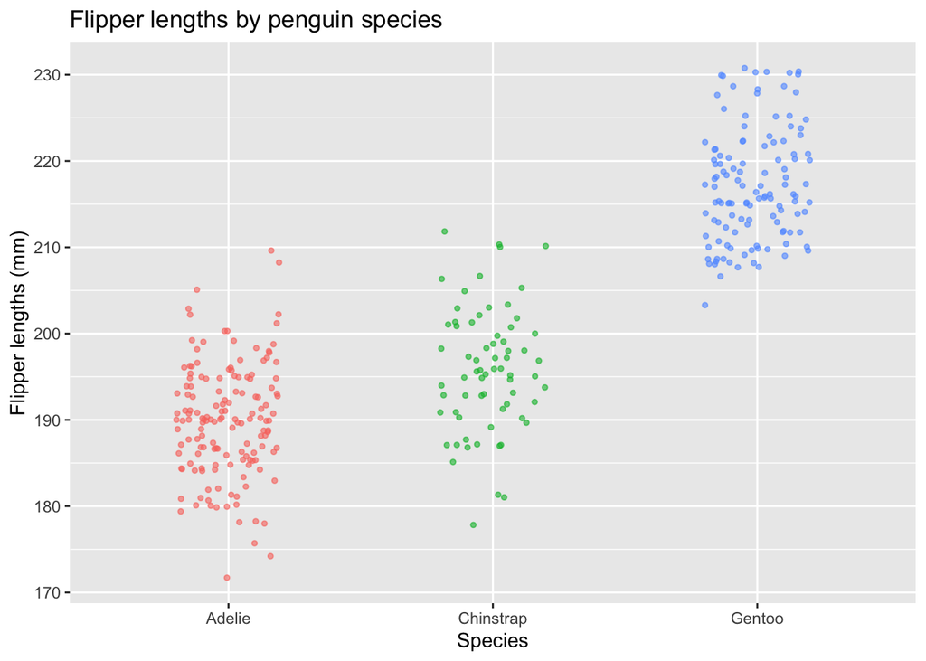

```r
#making a ggplot of penguin flipper length

ggplot(penguins, aes(x = species,
                   y = flipper_length_mm,
                   color = species)) +
  geom_jitter(size = 1, alpha = .6, width = 0.2,
              show.legend = FALSE) +     # removed legend since not needed
  labs(x = "Species",
       y = "Flipper lengths (mm)",
       title = "Flipper lengths by penguin species")
```

Now lets test what the standard zoom using scale_y_continuous looks like.

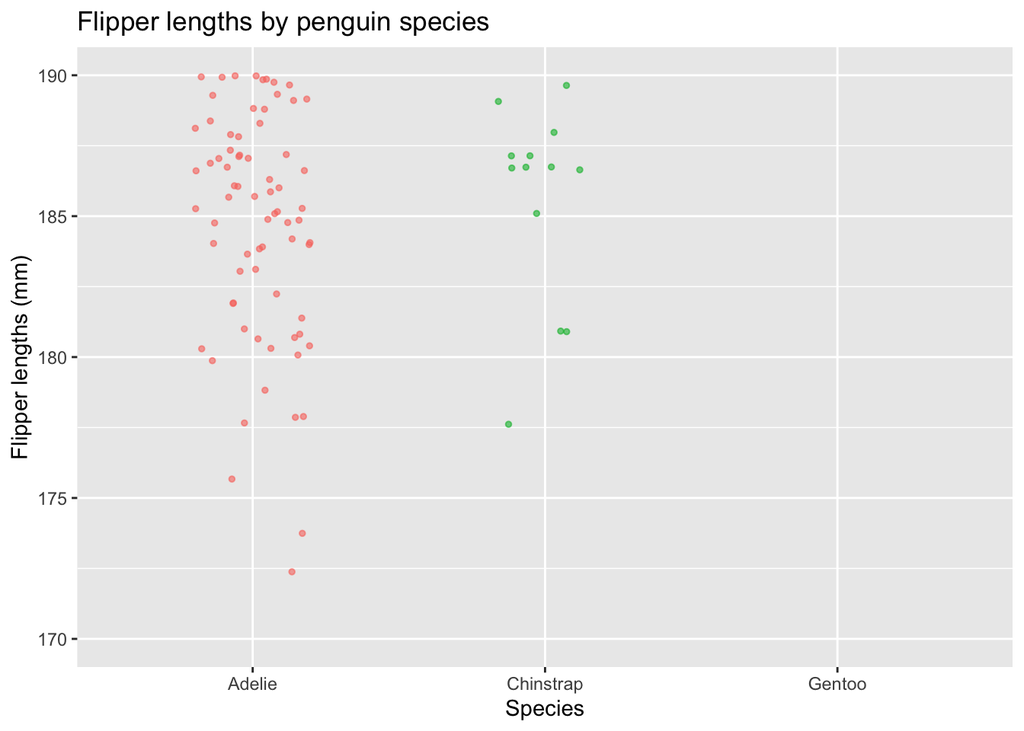

```r
ggplot(penguins, aes(x = species,
                   y = flipper_length_mm,
                   color = species)) +
  scale_y_continuous(limits = c(170, 190)) +
  geom_jitter(size = 1, alpha = .6, width = 0.2,
              show.legend = FALSE) +     # removed legend since not needed
  labs(x = "Species",
       y = "Flipper lengths (mm)",
       title = "Flipper lengths by penguin species")
```

As you can see the shape of the data changes here, this is because this sort of scaling sets anything outside of the set limits to NA and re-scales the data based on what is inside of the range.

Next lets look at the same range of data using the new function coord_cartesian()

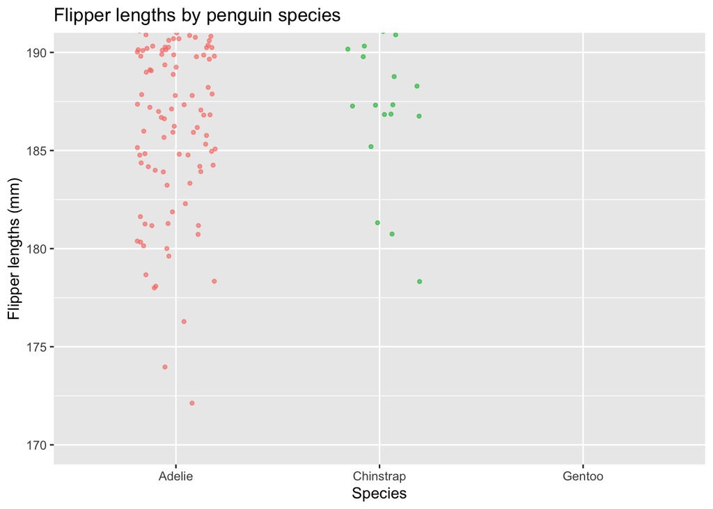

```r
ggplot(penguins, aes(x = species,
                   y = flipper_length_mm,
                   color = species)) +
  coord_cartesian(ylim = c(170, 190)) +
  geom_jitter(size = 1, alpha = .6, width = 0.2,
              show.legend = FALSE) +     # removed legend since not needed
  labs(x = "Species",
       y = "Flipper lengths (mm)",
       title = "Flipper lengths by penguin species")
```

Here we can see the shape of the data remains the same as from the main graph, we are simply zooming in on the set limits.

Using the penguin data the effect is there but it can be hard to see, lets look at some other data.

This data is from the R dataset called mtcars.

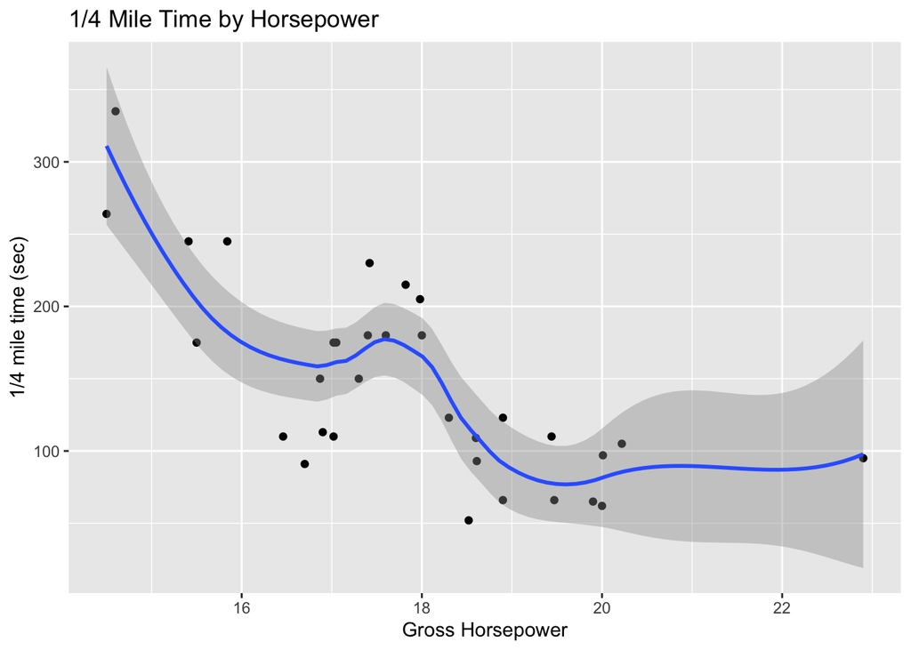

```r
plot <- ggplot(mtcars, aes(qsec, hp)) +
  geom_point() +
  geom_smooth() +
  labs(x="Gross Horsepower", y="1/4 mile time (sec)", title="1/4 Mile Time by Horsepower" )
plot
```

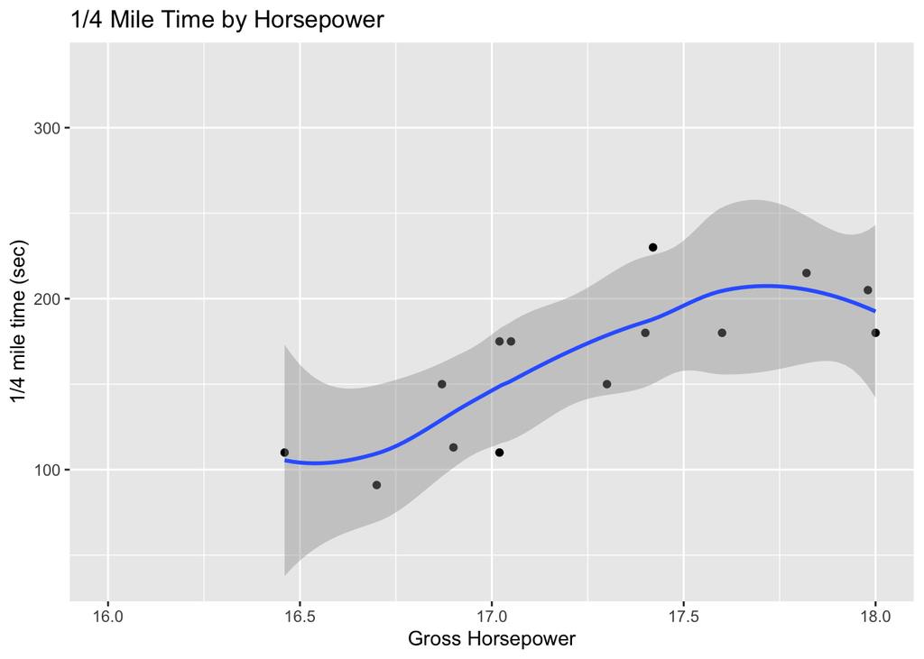

```r
plot + scale_x_continuous(limits = c(16, 18))
```

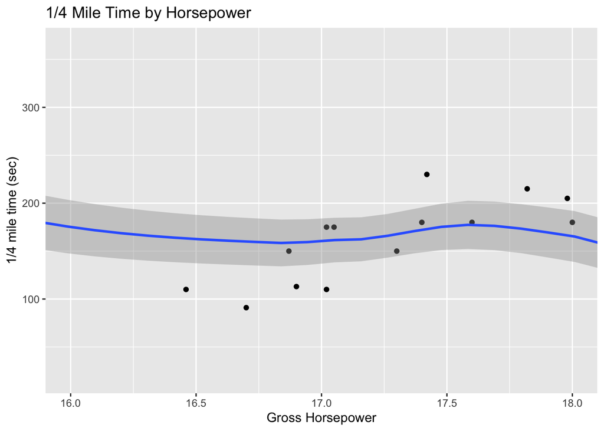

```r
plot + coord_cartesian(xlim = c(16, 18))
```

Here we can more clearly see the difference in the two scaling methods.

## 1.3 Is it helpful?

This function is useful especially when doing any sort of modeling. Using a loess curve and zooming in using the standard method would ignore your other data points and can change the shape of your modeled line. By instead using coord_cartesian() you can ensure that the zoomed in plot is only magnifying the original section of data and not changing the relationship between the data points in any way.

Presentation adapted from the webpage: https://ggplot2.tidyverse.org/reference/coord_cartesian.html